# Линейная алгебра. Практическая работа №10

[🌀 Home Page](https://olgabelitskaya.github.io/README.html) [📓 Previous](https://github.com/OlgaBelitskaya/linear_algebra_practice/blob/master/work1_9.ipynb) [📓 Next](https://github.com/OlgaBelitskaya/linear_algebra_practice/blob/master/work1_11.ipynb)

### Программные средства

[LaTeX. Mathematics](https://en.wikibooks.org/wiki/LaTeX/Mathematics)

[Sage. Linear Algebra](http://doc.sagemath.org/html/en/tutorial/tour_linalg.html)

[Numpy. Quickstart tutorial](https://docs.scipy.org/doc/numpy/user/quickstart.html#linear-algebra)

[R Functions - Tutorialspoint](https://www.tutorialspoint.com/r/r_functions.htm)

[Quick-R: User-Defined Functions](https://www.statmethods.net/management/userfunctions.html)

### Конспекты лекций

[АЛГЕБРА И ГЕОМЕТРИЯ ДЛЯ СТУДЕНТОВ-ФИЗИКОВ](http://math.phys.msu.ru/data/24/Algebra_and_geometry.pdf)

[АНАЛИТИЧЕСКАЯ ГЕОМЕТРИЯ](http://ffmgu.ru/images/1/16/%D0%9E%D0%B2%D1%87%D0%B8%D0%BD%D0%BD%D0%B8%D0%BA%D0%BE%D0%B2._%D0%9B%D0%B5%D0%BA%D1%86%D0%B8%D0%B8_%D0%90%D0%93._2009.pdf)

[math24.ru Окружность и эллипс](http://www.math24.ru/%D0%BE%D0%BA%D1%80%D1%83%D0%B6%D0%BD%D0%BE%D1%81%D1%82%D1%8C-%D0%B8-%D1%8D%D0%BB%D0%BB%D0%B8%D0%BF%D1%81.html)

[Computational Mathematics with SageMath](http://dl.lateralis.org/public/sagebook/sagebook-ba6596d.pdf)

[Introduction to Symbolic Computation](http://homepages.math.uic.edu/~jan/mcs320/mcs320.pdf)

# Линии второго порядка

## 1. Эллипс и окружность

#### Окружность

С центром в точке $A_0 (x_0;y_0)$ и радиусом $r$

$(x - x_0)^2 + (y - y_0)^2 = r^2$

Параметрические

$x = r * \cos t + x_0, y = r * \sin t + y_0, 0 \leq t < 2\pi$

Общее уравнение

$a * x^2 + a * y^2 + d * x + e * y + f = 0$

с центром в точке $\bigg(x_0 = -\frac{d}{2*a}; y_0 = -\frac{e}{2*a}\bigg)$ и радиусом $r = \frac{\sqrt{d^2 + e^2 - 4 * a * f}}{2 * |a|}$

Через три точки $A_1(x_1; y_1), \ A_2(x_2; y_2), \ A_3(x_3; y_3)$

$\begin{vmatrix} x^2+y^2 & x & y & 1 \\ x_1^2+y_1^2 & x_1 & y_1 & 1 \\ x_2^2+y_2^2 & x_2 & y_2 & 1 \\ x_3^2+y_3^2 & x_3 & y_3 & 1 \end{vmatrix} = 0$

Длина периметра

$L = 2 * \pi * r$

Площадь

$S =\pi * r^2$

#### Эллипс

С центром в точке $A_0 (x_0;y_0)$ и полуосями $p,q \ (p > q)$

Каноническое уравнение

$\frac{(x - x_0)^2}{p^2} + \frac{(y - y_0)^2}{q^2} = 1$

Эксцентриситет

$\epsilon = \frac{\sqrt{p^2 - q^2}}{p}$

Фокусы $F_1(x_0-\sqrt{p^2 - q^2};y_0), \ F_2(x_0+\sqrt{p^2 - q^2};y_0)$

$F_1M + F_2M = 2*p, \ \forall M \in ellipse$

Параметрические

$x = p * \cos t + x_0, y = q * \sin t + y_0, 0 \leq t < 2\pi$

Общее уравнение

$a * x^2 + b * x * y + c * y^2 + d * x + e * y + f = 0$

$b^2 - 4*a*c < 0$

С полуосями, параллельными координатным осям

$a * x^2 + с * y^2 + d * x + e * y + f = 0$

$a*c > 0$

Длина периметра

$L \approx \pi * \sqrt{2 * (p^2 + q^2)}$

Площадь

$S =\pi * p * q$

Касательная в точке $M (x_M; y_M)$

$\frac{(x - x_0)*(x_M - x_0)}{p^2} + \frac{(y - y_0)*(y_M - y_0)}{q^2} = 1$

```python
var('x,y,x0,y0,a,b,c,d,e,f,p,q,r,t')
eq1=[(x-x0)**2+(y-y0)**2-r**2==0,
     x==r*cos(t)+x0,y==r*sin(t)+y0,
     (x-x0)**2/p**2+(y-y0)**2/q**2-1==0,
     a*x**2+b*x*y+c*y**2+d*x+e*y+f==0]
```

```python
solutions1=[solve([eq1[0],x0==1,y0==-1,r==2],x0,y0,r,y),
            solve([eq1[1],eq1[2],
                   x0==-1,y0==1,r==3],x0,y0,r,x,y),
            solve([eq1[3],x0==1,y0==-1,
                   p==5,q==4],x0,y0,p,q,y),
            solve([eq1[4],a==1,b==1,c==1,
                   d==2,e==6,f==3],a,b,c,d,e,f,y)]
for s in solutions1: pretty_print(s)
```

$$\newcommand{\Bold}[1]{\mathbf{#1}}\left[\left[x_{0} = 1, y_{0} = \left(-1\right), r = 2, y = -\sqrt{-x^{2} + 2 \, x + 3} - 1\right], \left[x_{0} = 1, y_{0} = \left(-1\right), r = 2, y = \sqrt{-x^{2} + 2 \, x + 3} - 1\right]\right]$$

$$\newcommand{\Bold}[1]{\mathbf{#1}}\left[\left[x_{0} = \left(-1\right), y_{0} = 1, r = 3, x = 3 \, \cos\left(t\right) - 1, y = 3 \, \sin\left(t\right) + 1\right]\right]$$

$$\newcommand{\Bold}[1]{\mathbf{#1}}\left[\left[x_{0} = 1, y_{0} = \left(-1\right), p = 5, q = 4, y = \frac{4}{5} \, \sqrt{-x^{2} + 2 \, x + 24} - 1\right], \left[x_{0} = 1, y_{0} = \left(-1\right), p = 5, q = 4, y = -\frac{4}{5} \, \sqrt{-x^{2} + 2 \, x + 24} - 1\right]\right]$$

$$\newcommand{\Bold}[1]{\mathbf{#1}}\left[\left[a = 1, b = 1, c = 1, d = 2, e = 6, f = 3, y = -\frac{1}{2} \, x + \frac{1}{2} \, \sqrt{-3 \, x^{2} + 4 \, x + 24} - 3\right], \left[a = 1, b = 1, c = 1, d = 2, e = 6, f = 3, y = -\frac{1}{2} \, x - \frac{1}{2} \, \sqrt{-3 \, x^{2} + 4 \, x + 24} - 3\right]\right]$$

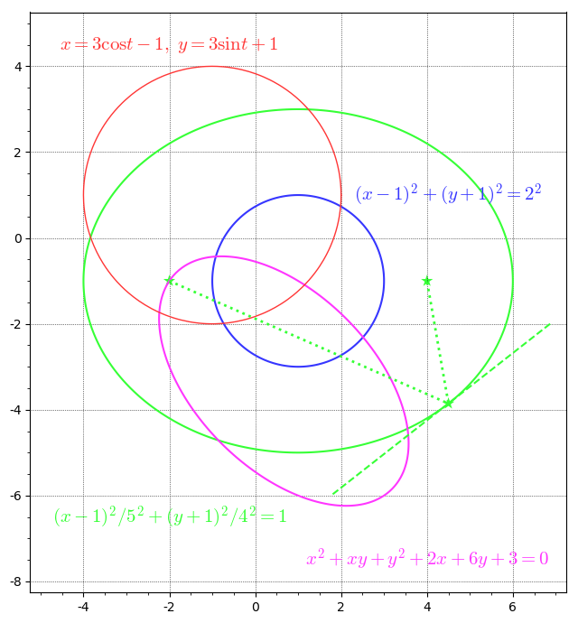

```python
f1=[(x-1)**2+(y+1)**2-2**2,[3*cos(t)-1,3*sin(t)+1],
    (x-1)**2/5**2+(y+1)**2/4**2-1,
    1*x**2+1*x*y+1*y**2+2*x+6*y+3]
colors=['#3636ff','#ff3636','#36ff36','#ff36ff']
text_xy=[(4.5,1),(-2,4.5),(-2,-6.5),(4,-7.5)]
labels=[r'$(x-1)^2+(y+1)^2=2^2$',
        r'$x=3 \cos t-1, \ y=3 \sin t+1$',
        r'$(x-1)^2/5^2+(y+1)^2/4^2=1$',
        r'$x^2+xy+y^2+2x+6y+3=0$']
p1=implicit_plot(f1[0],(-2,4),(-4,2),color=colors[0])+\
   parametric_plot(f1[1],(0,2*pi),color=colors[1])+\
   implicit_plot(f1[2],(-5,7),(-5,5),color=colors[2])+\
   implicit_plot(f1[3],(-5,5),(-8,1),color=colors[3])
p11=points([(-2,-1),(4,-1),(4.5,-4/5*sqrt(-4.5^2+2*4.5+24)-1)],
            color=colors[2],size=100,marker='*')
p12=line([(-2,-1),(4.5,-4/5*sqrt(-4.5^2+2*4.5+24)-1),(4,-1)],
          linestyle=':',thickness=2,color=colors[2])
p13=implicit_plot((x-1)*(4.5-1)/5**2+(y+1)*\
                  (-4/5*sqrt(-4.5^2+2*4.5+24)-1+1)/4**2-1,
                  (1,7),(-6,-2),linestyle='--',color=colors[2])
t1=sum([text(labels[i],text_xy[i],
             color=colors[i],fontsize=15) for i in [0..3]])
(p1+t1+p11+p12+p13).show(gridlines=True,figsize=(7,7))
```

```python
x0,y0,p,q=1,-1,5,4
f1x,f1y=x0-sqrt(p^2-q^2),y0; f2x,f2y=x0+sqrt(p^2-q^2),y0
xm=4.5; ym=-4/5*sqrt(-xm^2+2*xm+24)-1
((xm-f1x)^2+(ym-f1y)^2)^0.5+((xm-f2x)^2+(ym-f2y)^2)^0.5==2*p
```

```
True
```

```python
import numpy,sympy,pylab
sympy.init_printing(use_unicode=True)
from matplotlib.lines import Line2D
x,y,x0,y0,a,b,c,d,e,f,p,q,r,t=\
sympy.symbols('x,y,x0,y0,a,b,c,d,e,f,p,q,r,t')
eq1=[(x-x0)**2+(y-y0)**2-r**2,
     [x-r*cos(t)-x0,y-r*sin(t)-y0],
     (x-x0)**2/p**2+(y-y0)**2/q**2-1,
     a*x**2+b*x*y+c*y**2+d*x+e*y+f]
X1=numpy.linspace(start=-1,stop=3,num=100)
X2=numpy.linspace(start=-4,stop=6,num=100)
T=numpy.linspace(start=0,stop=6.3,num=100)
X=numpy.linspace(start=-2.3,stop=3.6,num=100),
Y=numpy.linspace(start=-6.3,stop=-0.3,num=100)
X,Y=numpy.meshgrid(X,Y)
def circle1(x0,y0,r,x):
    return numpy.array([-(r**2-(x-x0)**2)**0.5+y0,
                        (r**2-(x-x0)**2)**0.5+y0])
def circle2(x0,y0,r,t):
    return numpy.array([r*numpy.cos(t)+x0,
                        r*numpy.sin(t)+y0])
def ellipse1(x0,y0,p,q,x):
    return numpy.array([q/p*(p**2-(x-x0)**2)**0.5+y0,
                        -q/p*(p**2-(x-x0)**2)**0.5+y0])
def ellipse2(a,b,c,d,e,f,x,y):
    return a*x**2+b*x*y+c*y**2+d*x+e*y+f
```

```python
solutions1=[sympy.solve([eq1[0],x0-1,y0+1,r-2],
                        x0,y0,r,y),
            sympy.solve([eq1[1][0],eq1[1][1],
                         x0+1,y0-1,r-3],x0,y0,r,x,y),
            sympy.solve([eq1[2],x0-1,y0+1,
                         p-5,q-4],x0,y0,p,q,y),
            sympy.solve([eq1[3],a-1,b-1,c-1,d-2,e-6,f-3],
                        a,b,c,d,e,f,y)]
for s in solutions1: display(s); print('\n')
```

$\displaystyle \left[ \left( 1, \ -1, \ 2, \ - \sqrt{- \left(x - 3\right) \left(x + 1\right)} - 1\right), \ \left( 1, \ -1, \ 2, \ \sqrt{- \left(x - 3\right) \left(x + 1\right)} - 1\right)\right]$

$\displaystyle \left\{ r : 3, \ x : 3 \cos{\left(t \right)} - 1, \ x_{0} : -1, \ y : 3 \sin{\left(t \right)} + 1, \ y_{0} : 1\right\}$

$\displaystyle \left[ \left( 1, \ -1, \ 5, \ 4, \ - \frac{4 \sqrt{- \left(x - 6\right) \left(x + 4\right)}}{5} - 1\right), \ \left( 1, \ -1, \ 5, \ 4, \ \frac{4 \sqrt{- \left(x - 6\right) \left(x + 4\right)}}{5} - 1\right)\right]$

$\displaystyle \left[ \left( 1, \ 1, \ 1, \ 2, \ 6, \ 3, \ - \frac{x}{2} - \frac{\sqrt{- 3 x^{2} + 4 x + 24}}{2} - 3\right), \ \left( 1, \ 1, \ 1, \ 2, \ 6, \ 3, \ - \frac{x}{2} + \frac{\sqrt{- 3 x^{2} + 4 x + 24}}{2} - 3\right)\right]$

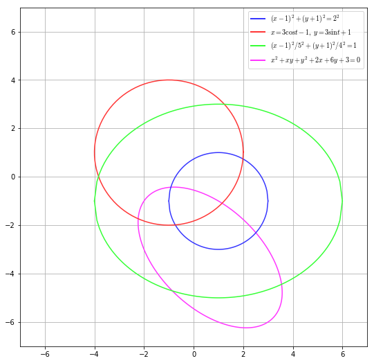

```python
fig=pylab.figure(figsize=(9,9))
ax=fig.add_subplot(111); pylab.grid()
colors=['#3636ff','#ff3636','#36ff36','#ff36ff']
lines=[Line2D([0],[0],color=c,linewidth=2,
              linestyle='-') for c in colors]
labels=[r'$(x-1)^2+(y+1)^2=2^2$',
        r'$x=3 \cos t-1, \ y=3 \sin t+1$',
        r'$(x-1)^2/5^2+(y+1)^2/4^2=1$',
        r'$x^2+xy+y^2+2x+6y+3=0$']
[ax.plot(X1,circle1(1,-1,2,X1)[i],
         color=colors[0]) for i in [0,1]]
ax.plot(circle2(-1,1,3,T)[0],
        circle2(-1,1,3,T)[1],color=colors[1])
[ax.plot(X2,ellipse1(1,-1,5,4,X2)[i],
         color=colors[2]) for i in [0,1]]
ax.contour(X,Y,ellipse2(1,1,1,2,6,3,X,Y),
           [0],colors=colors[3])
ax.set_xlim(-7,7); ax.set_ylim(-7,7)
ax.legend(lines,labels,loc=1); pylab.show()
```

```python
(a*((x+d/(2*a))^2+(y+e/(2*a))^2-\
(sqrt(d^2+e^2-4*a*f)/(2*a))^2)).simplify()
```

$\displaystyle a x^{2} + a y^{2} + d x + e y + f$

```python
%%r
X1<-seq(from=-1,to=3,by=0.1)
X2<-seq(from=-4,to=6,by=0.1)
T<-seq(from=0,to=2*pi+0.1,by=0.1)
circle1<-function(x0,y0,r,x){
    list(-(r**2-(x-x0)**2)**0.5+y0,
         (r**2-(x-x0)**2)**0.5+y0)}
circle2<-function(x0,y0,r,t){
    list(r*cos(t)+x0,
         r*sin(t)+y0)}
ellipse1<-function(x0,y0,p,q,x){
    list(-q/p*(p**2-(x-x0)**2)**0.5+y0,
         q/p*(p**2-(x-x0)**2)**0.5+y0)}
ellipse2<-function(a,b,c,d,e,f,t){
    M<-matrix(c(f,d/2,e/2,d/2,a,b/2,e/2,b/2,c),
              nrow=3,byrow=TRUE)
    m<-matrix(c(a,b/2,b/2,c),nrow=2,byrow=TRUE)
    mlambda<-eigen(m)$values
    p<-sqrt(-det(M)/(det(m)*mlambda[1]))
    q<-sqrt(-det(M)/(det(m)*mlambda[2]))
    x0<-(b*e-2*c*d)/(4*a*c-b^2)
    y0<-(b*d-2*a*e)/(4*a*c-b^2)
    phi<-(pi/2-atan((a-c)/b))/2
    x<-x0+p*cos(t)*cos(phi)-q*sin(t)*sin(phi)
    y<-y0+p*cos(t)*sin(phi)+q*sin(t)*cos(phi)
    list(x,y)}
Y1<-sapply(X1,circle1,x0=1,y0=-1,r=2)
XY<-sapply(T,circle2,x0=-1,y0=1,r=3)
Y2<-sapply(X2,ellipse1,x0=1,y0=-1,p=5,q=4)
XY2<-sapply(T,ellipse2,a=1,b=1,c=1,d=2,e=6,f=3)
library(grDevices); library(Matrix)
```

```
[1] "Matrix"    "tools"     "stats"     "graphics"  "grDevices" "utils"
[7] "datasets"  "methods"   "base"
```

```python
%%r
svg(filename="Rplots.svg",width=7,height=7,pointsize=12,
    onefile=TRUE,family="times",bg="white",
    antialias=c("default","none","gray","subpixel"))
cols<-c('#3636ff','#ff3636','#36ff36','#ff36ff')
labs<-c('(x-1)^2+(y+1)^2=2^2','x=3cos(t)-1, y=3sin(t)+1',
        '(x-1)^2/5^2+(y+1)^2/4^2=1','x^2+xy+y^2+2x+6y+3=0')
plot(X1,Y1[1,],col=cols[1],type='l',
     lwd=3,xlim=c(-7,7),ylim=c(-7,7),xlab='x',ylab='y')
lines(X1,Y1[2,],col=cols[1],lwd=3)
lines(XY[1,],XY[2,],col=cols[2],lwd=3)
lines(X2,Y2[1,],col=cols[3],lwd=3)
lines(X2,Y2[2,],col=cols[3],lwd=3)
lines(XY2[1,],XY2[2,],col=cols[4],lwd=3)
legend(0,6.9,labs,col=cols,lwd=3); grid(); dev.off()
```

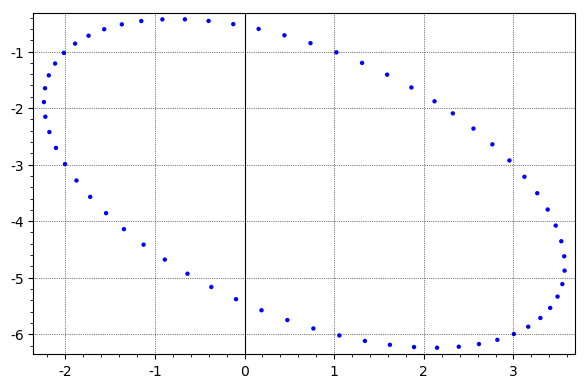

```python
X2=[2.119633,1.861132,1.590697,1.311029,1.024923,0.7352368,0.4448658,0.156711,-0.1263485,
    -0.4014845,-0.6659478,-0.9170961,-1.15242,-1.369568,-1.566371,-1.740862,-1.891298,-2.016175,
    -2.114246,-2.184532,-2.226329,-2.23922,-2.223077,-2.17806,-2.10462,-2.00349,-1.87568,
    -1.722469,-1.545386,-1.3462,-1.126903,-0.8896854,-0.636917,-0.3711236,-0.09496087,0.1888117,
    0.4773589,0.7677976,1.057226,1.342752,1.621522,1.890752,2.147752,2.389953,2.614935,
    2.820451,3.004447,3.165085,3.300759,3.410114,3.492058,3.545771,3.570718,3.566648,3.533602,
    3.471911,3.382191,3.265338,3.12252,2.955164,2.764942,2.553755,2.323713]
Y2=[-1.880367,-1.636384,-1.409356,-1.201552,-1.015048,-0.8517076,-0.7131628,-0.6007978,-0.5157354,
    -0.4588255,-0.4306367,-0.4314508,-0.4612595,-0.519765,-0.6063827,-0.7202472,-0.8602209,-1.024905,
    -1.212654,-1.421593,-1.649632,-1.894495,-2.153734,-2.42476,-2.704863,-2.991246,-3.281047,
    -3.571371,-3.859316,-4.142005,-4.416615,-4.680401,-4.930727,-5.165093,-5.381156,-5.576758,
    -5.749945,-5.898986,-6.022391,-6.118929,-6.187633,-6.227819,-6.239083,-6.221315,-6.17469,
    -6.099676,-5.997021,-5.867752,-5.71316,-5.534789,-5.334422,-5.11406,-4.875907,-4.62234,-4.355894,
    -4.079231,-3.795115,-3.506385,-3.215926,-2.926641,-2.641419,-2.36311,-2.094495]
list_plot(list(zip(X2,Y2)),gridlines=True,frame=True)
```

## 2. Гипербола

С центром в точке $A_0 (x_0;y_0)$ и действительной и мнимой полуосями $p,q$

Каноническое уравнение

$\frac{(x - x_0)^2}{p^2} - \frac{(y - y_0)^2}{q^2} = 1$

Эксцентриситет

$\epsilon = \frac{\sqrt{p^2 + q^2}}{p}$

Уравнения асимптот гиперболы

$y = \pm \frac{q}{p} * (x - x_0) + y_0$

Фокусы $F_1(x_0-\sqrt{p^2 + q^2}; y_0), \ F_2(x_0+\sqrt{p^2 + q^2}; y_0)$

$|F_1M - F_2M| = 2*p, \ \forall M \in hyperbole$

Параметрические (правая ветвь)

$x = p * \cosh t + x_0, y = q * \sinh t + y_0, 0 \leq t < 2\pi$

Общее уравнение

$a * x^2 + b * x * y + с * y^2 + d * x + e * y + f = 0$

$b^2 - 4*a*c > 0$

С полуосями, параллельными координатным осям

$a * x^2 + с * y^2 + d * x + e * y + f = 0$

$a*c < 0$

Касательная в точке $M (x_M; y_M)$

$\frac{(x - x_0)*(x_M - x_0)}{p^2} - \frac{(y - y_0)*(y_M - y_0)}{q^2} = 1$

```python
var('x,y,x0,y0,a,b,c,d,e,f,p,q,r,t')
eq2=[(x-x0)**2/p**2-(y-y0)**2/q**2-1==0,
     [x==p*cosh(t)+x0,y==q*sinh(t)+y0],
     a*x**2+b*x*y+c*y**2+d*x+e*y+f==0]
solutions2=[solve([eq2[0],x0==1,y0==-1,
                   p==3,q==4],x0,y0,p,q,y),
            solve([eq2[1][0],eq2[1][1],
                   x0==-1,y0==1,p==3,q==4],x0,y0,p,q,x,y),
            solve([eq2[2],a==1,b==1,c==-1,
                   d==2,e==6,f==3],a,b,c,d,e,f,y)]
for s in solutions2: pretty_print(s)
```

$$\newcommand{\Bold}[1]{\mathbf{#1}}\left[\left[x_{0} = 1, y_{0} = \left(-1\right), p = 3, q = 4, y = \frac{4}{3} \, \sqrt{x^{2} - 2 \, x - 8} - 1\right], \left[x_{0} = 1, y_{0} = \left(-1\right), p = 3, q = 4, y = -\frac{4}{3} \, \sqrt{x^{2} - 2 \, x - 8} - 1\right]\right]$$

$$\newcommand{\Bold}[1]{\mathbf{#1}}\left[\left[x_{0} = \left(-1\right), y_{0} = 1, p = 3, q = 4, x = 3 \, \cosh\left(t\right) - 1, y = 4 \, \sinh\left(t\right) + 1\right]\right]$$

$$\newcommand{\Bold}[1]{\mathbf{#1}}\left[\left[a = 1, b = 1, c = \left(-1\right), d = 2, e = 6, f = 3, y = \frac{1}{2} \, x + \frac{1}{2} \, \sqrt{5 \, x^{2} + 20 \, x + 48} + 3\right], \left[a = 1, b = 1, c = \left(-1\right), d = 2, e = 6, f = 3, y = \frac{1}{2} \, x - \frac{1}{2} \, \sqrt{5 \, x^{2} + 20 \, x + 48} + 3\right]\right]$$

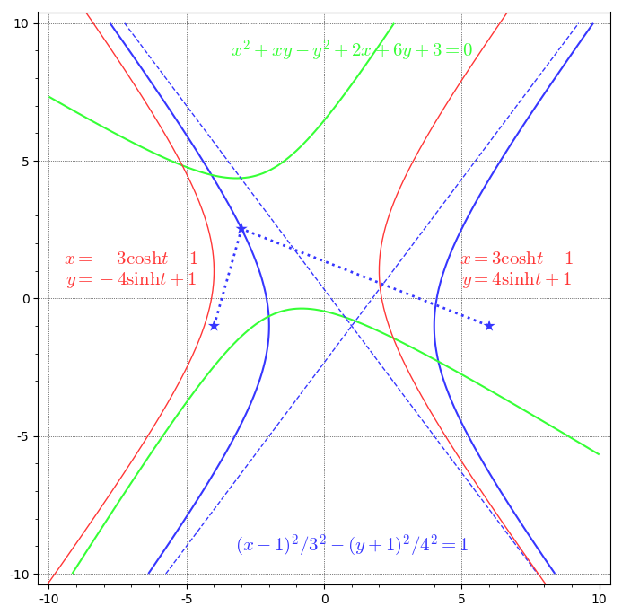

```python
f2=[(x-1)**2/3**2-(y+1)**2/4**2-1,
    [(3*cosh(t)-1,4*sinh(t)+1),
     (-3*cosh(t)-1,-4*sinh(t)+1)],
     1*x**2+1*x*y-1*y**2+2*x+6*y+3]
f21=[y-4/3*(x-1)+1,y+4/3*(x-1)+1]
f22=[(1-(3^2+4^2)^0.5,-1),
     (-3,4/3*sqrt((-3)^2-2*(-3)-8)-1),
     (1+(3^2+4^2)^0.5,-1)]
s=(-10,10); colors=['#3636ff',2*['#ff3636'],'#36ff36']
text_xy=[(1,-9),[(7,1),(-7,1)],(1,9)]
labels=[r'$(x-1)^2/3^2-(y+1)^2/4^2=1$',
       [r'$x=3 \cosh t-1$'+'\n'+r'$y=4 \sinh t+1$',
        r'$x=-3 \cosh t-1$'+'\n'+r'$y=-4 \sinh t+1$'],
        r'$x^2+xy-y^2+2x+6y+3=0$']
p2=sum([implicit_plot(f2[i],s,s,color=colors[i])
        for i in [0,2]])+\
   sum([parametric_plot(f2[1][i],(-2,2),
        color=colors[1][i]) for i in [0,1]])
p21=sum([implicit_plot(f21[i],s,s,linestyle='--',
                       linewidth=1,color=colors[0])
         for i in [0,1]])+\
    line(f22,linestyle=':',thickness=2,color=colors[0])+\
    points(f22,color=colors[0],size=100,marker='*')
t2=sum([text(labels[i],text_xy[i],color=colors[i],
             fontsize=15) for i in [0,2]])+\
   sum([text(labels[1][i],text_xy[1][i],color=colors[1][i],
             fontsize=15) for i in [0,1]])
(p2+p21+t2).show(gridlines=True,figsize=(7,7),
                 xmax=10,xmin=-10,ymax=10,ymin=-10)
```

```python
x0,y0,p,q=1,-1,3,4
f1x,f1y=x0-sqrt(p^2+q^2),y0; f2x,f2y=x0+sqrt(p^2+q^2),y0
xm=-3; ym=4/3*sqrt(xm^2-2*xm-8)-1
diff_distance=\
abs(((xm-f1x)^2+(ym-f1y)^2)^0.5-((xm-f2x)^2+(ym-f2y)^2)^0.5)
diff_distance==2*p,round(diff_distance)==2*p
```

```
(6.00000000000000 == 6, True)
```

```python
import numpy,sympy,pylab
sympy.init_printing(use_unicode=True)
from matplotlib.lines import Line2D
x,y,x0,y0,a,b,c,d,e,f,p,q,t=\
sympy.symbols('x,y,x0,y0,a,b,c,d,e,f,p,q,t')
eq2=[(x-x0)**2/p**2-(y-y0)**2/q**2-1,
    [x-p*cosh(t)-x0,y-q*sinh(t)-y0],
     a*x**2+b*x*y+c*y**2+d*x+e*y+f]
solutions2=[sympy.solve([eq2[0],x0-1,y0+1,
                         p-3,q-4],x0,y0,p,q,y),
            sympy.solve([eq2[1][0],eq2[1][1],
                         x0+1,y0-1,p-3,q-4],x0,y0,p,q,x,y),
            sympy.solve([eq2[2],a-1,b-1,c+1,d-2,e-6,f-3],
                        a,b,c,d,e,f,y)]
for s in solutions2: display(s); print('\n')
```

$\displaystyle \left[ \left( 1, \ -1, \ 3, \ 4, \ - \frac{4 \sqrt{\left(x - 4\right) \left(x + 2\right)}}{3} - 1\right), \ \left( 1, \ -1, \ 3, \ 4, \ \frac{4 \sqrt{\left(x - 4\right) \left(x + 2\right)}}{3} - 1\right)\right]$

$\displaystyle \left\{ p : 3, \ q : 4, \ x : 3 \cosh{\left(t \right)} - 1, \ x_{0} : -1, \ y : 4 \sinh{\left(t \right)} + 1, \ y_{0} : 1\right\}$

$\displaystyle \left[ \left( 1, \ 1, \ -1, \ 2, \ 6, \ 3, \ \frac{x}{2} - \frac{\sqrt{5 x^{2} + 20 x + 48}}{2} + 3\right), \ \left( 1, \ 1, \ -1, \ 2, \ 6, \ 3, \ \frac{x}{2} + \frac{\sqrt{5 x^{2} + 20 x + 48}}{2} + 3\right)\right]$

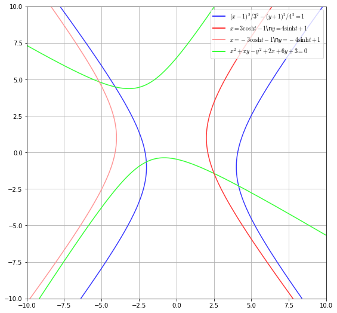

```python
T=numpy.linspace(start=-2,stop=2,num=100)
X=numpy.linspace(start=-10,stop=10,num=100)
X,Y=numpy.meshgrid(X,X)
def hyperbole1(x0,y0,p,q,x,y):
    return (x-x0)**2/p**2-(y-y0)**2/q**2-1
def hyperbole2(x0,y0,p,q,t):
    return numpy.array([p*cosh(t)+x0,q*sinh(t)+y0,
                        -p*cosh(t)+x0,-q*sinh(t)+y0])
def hyperbole3(a,b,c,d,e,f,x,y):
    return a*x**2+b*x*y+c*y**2+d*x+e*y+f
fig=pylab.figure(figsize=(9,9))
ax=fig.add_subplot(111); pylab.grid()
colors=['#3636ff','#ff3636','#ff9696','#36ff36']
lines=[Line2D([0],[0],color=c,linewidth=2,
              linestyle='-') for c in colors]
labels=[r'$(x-1)^2/3^2-(y+1)^2/4^2=1$',
        r'$x=3 \cosh t-1$\n$y=4 \sinh t+1$',
        r'$x=-3 \cosh t-1$\n$y=-4 \sinh t+1$',
        r'$x^2+xy-y^2+2x+6y+3=0$']
ax.contour(X,Y,hyperbole1(1,-1,3,4,X,Y),
           [0],colors=colors[0])
[ax.plot(hyperbole2(-1,1,3,4,T)[2*i],
         hyperbole2(-1,1,3,4,T)[2*i+1],
         color=colors[i+1]) for i in [0,1]]
ax.contour(X,Y,hyperbole3(1,1,-1,2,6,3,X,Y),
           [0],colors=colors[3])
ax.set_xlim(-10,10); ax.set_ylim(-10,10)
ax.legend(lines,labels,loc=1); pylab.show()
```

```python
%%r
X<-Y<-seq(from=-12,to=12,by=0.1)
T<-seq(from=-2,to=2,by=0.05)
hyperbole1<-function(x0,y0,p,q,x){
    list(-q/p*((x-x0)**2-p**2)**0.5+y0,
         q/p*((x-x0)**2-p**2)**0.5+y0)}
hyperbole2<-function(x0,y0,p,q,t){
    list(p*cosh(t)+x0,q*sinh(t)+y0,
         -p*cosh(t)+x0,
         -q*sinh(t)+y0)}
hyperbole3<-function(a,b,c,d,e,f,X,Y){
    func<-function(x,y){a*x**2+b*x*y+c*y**2+d*x+e*y+f}
    Z<-outer(X,Y,func); Z[is.na(Z)]<-0; Z}
Y1<-sapply(X,hyperbole1,x0=1,y0=-1,p=3,q=4)
XY<-sapply(T,hyperbole2,x0=-1,y0=1,p=3,q=4)
XY2<-hyperbole3(1,1,-1,2,6,3,X,Y)
dim(data.frame(XY2))
```

```
[1] 241 241
```

```python
%%r
svg(filename="Rplots.svg",width=7,height=7,pointsize=12,
    onefile=TRUE,family="times",bg="white",
    antialias=c("default","none","gray","subpixel"))
cols<-c('#3636ff','#ff3636','#ff9696','#36ff36')
labs<-c('(x-1)^2/3^2-(y+1)^2/4^2=1','x=3 cosh t-1 \n y=4 sinh t+1',
        'x=-3 cosh t-1 \n y=-4 sinh t+1','x^2+xy-y^2+2x+6y+3=0')
contour(X,X,data.matrix(data.frame(XY2)),levels=0,
        col=cols[4],lwd=3,xlim=c(-10,10),ylim=c(-10,10),
        xlab='x',ylab='y')
lines(X,Y1[1,],col=cols[1],lwd=3)
lines(X,Y1[2,],col=cols[1],lwd=3)
lines(XY[1,],XY[2,],col=cols[2],lwd=3)
lines(XY[3,],XY[4,],col=cols[3],lwd=3)
legend(0,10,labs,col=cols,lwd=3,cex=0.9)
grid(); dev.off()
```

## 3. Парабола

Каноническое с вершиной $A_0(x_0; y_0)$

$(y - y_0)^2 = 2 * p * (x - x_0)$

Фокус $F(x_0 + \frac{p}{2}; y_0)$

Касательная в точке $M (x_M; y_M)$

$(y - y_0) * (y_M - y_0) = p * (x + x_M - 2 * x_0)$

Общее уравнение

$a * x^2 + b * x * y + с * y^2 + d * x + e * y + f = 0$

$b^2 - 4*a*c = 0$

Ось симметрии параллельна оси $Oy$

$a * x^2 + d * x + e * y + f = 0$

Ось симметрии параллельна оси $Ox$

$c * y^2 + d * x + e * y + f = 0$

```python
var('x,y,x0,y0,a,b,c,d,e,f,p')
eq3=[(y-y0)**2==2*p*(x-x0),
     a*x**2+b*x*y+c*y**2+d*x+e*y+f==0,
     a*x**2+d*x+e*y+f==0]
solutions3=[solve([eq3[0],x0==1,y0==-1,p==3],x0,y0,p,y),
            solve([eq3[1],a==1,b==-4,c==4,d==1,e==4,f==3],
                  a,b,c,d,e,f,y),
            solve([eq3[2],a==2,d==4,e==1,f==-7],a,d,e,f,y)]
for s in solutions3: pretty_print(s)
```

$$\newcommand{\Bold}[1]{\mathbf{#1}}\left[\left[x_{0} = 1, y_{0} = \left(-1\right), p = 3, y = -\sqrt{6 \, x - 6} - 1\right], \left[x_{0} = 1, y_{0} = \left(-1\right), p = 3, y = \sqrt{6 \, x - 6} - 1\right]\right]$$

$$\newcommand{\Bold}[1]{\mathbf{#1}}\left[\left[a = 1, b = \left(-4\right), c = 4, d = 1, e = 4, f = 3, y = \frac{1}{2} \, x + \frac{1}{2} \, \sqrt{-3 \, x - 2} - \frac{1}{2}\right], \left[a = 1, b = \left(-4\right), c = 4, d = 1, e = 4, f = 3, y = \frac{1}{2} \, x - \frac{1}{2} \, \sqrt{-3 \, x - 2} - \frac{1}{2}\right]\right]$$

$$\newcommand{\Bold}[1]{\mathbf{#1}}\left[\left[a = 2, d = 4, e = 1, f = \left(-7\right), y = -2 \, x^{2} - 4 \, x + 7\right]\right]$$

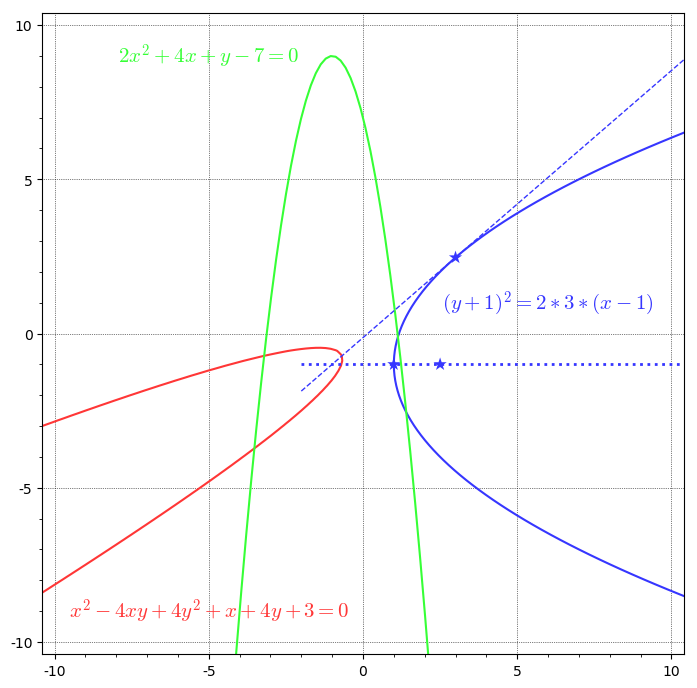

```python
f3=[(y+1)**2-2*3*(x-1),
    1*x**2-4*x*y+4*y**2+1*x+4*y+3,
    2*x**2+4*x+1*y-7]
s=(-12,12); colors=['#3636ff','#ff3636','#36ff36']
text_xy=[(6,1),(-5,-9),(-5,9)]
labels=[r'$(y+1)^2=2*3*(x-1)$',
        r'$x^2-4xy+4y^2+x+4y+3=0$',
        r'$2x^2+4x+y-7=0$']
p3=sum([implicit_plot(f3[i],s,s,color=colors[i])
        for i in [0..2]])+\
   implicit_plot((y+1)*(sqrt(6*3-6)-1+1)-3*(x+3-2*1),
                 (-2,12),(-11,9),linestyle='--',
                 linewidth=1,color=colors[0])+\
   line([(-2,-1),(12,-1)],linestyle=':',
         thickness=2,color=colors[0])+\
   points([(1,-1),(1+3/2,-1),(3,sqrt(6*3-6)-1)],
           color=colors[0],size=100,marker='*')
t3=sum([text(labels[i],text_xy[i],
             color=colors[i],fontsize=15)
        for i in [0..2]])
(p3+t3).show(gridlines=True,figsize=(7,7),
             xmax=10,xmin=-10,ymax=10,ymin=-10)
```

```python
import numpy,sympy,pylab
sympy.init_printing(use_unicode=True)
from matplotlib.lines import Line2D
x,y,x0,y0,a,b,c,d,e,f,p=\
sympy.symbols('x,y,x0,y0,a,b,c,d,e,f,p')
eq3=[(y-y0)**2-2*p*(x-x0),
     a*x**2+b*x*y+c*y**2+d*x+e*y+f,
     a*x**2+d*x+e*y+f]
solutions3=[sympy.solve([eq3[0],x0-1,y0+1,p-3],
                        x0,y0,p,y),
            sympy.solve([eq3[1],a-1,b+4,c-4,d-1,e-4,f-3],
                        a,b,c,d,e,f,y),
            sympy.solve([eq3[2],a-2,d-4,e-1,f+7],
                        a,d,e,f,y)]
for s in solutions3: display(s); print('\n')
```

$\displaystyle \left[ \left( 1, \ -1, \ 3, \ - \sqrt{6} \sqrt{x - 1} - 1\right), \ \left( 1, \ -1, \ 3, \ \sqrt{6} \sqrt{x - 1} - 1\right)\right]$

$\displaystyle \left[ \left( 1, \ -4, \ 4, \ 1, \ 4, \ 3, \ \frac{x}{2} - \frac{\sqrt{- 3 x - 2}}{2} - \frac{1}{2}\right), \ \left( 1, \ -4, \ 4, \ 1, \ 4, \ 3, \ \frac{x}{2} + \frac{\sqrt{- 3 x - 2}}{2} - \frac{1}{2}\right)\right]$

$\displaystyle \left[ \left( 2, \ 4, \ 1, \ -7, \ - 2 x^{2} - 4 x + 7\right)\right]$

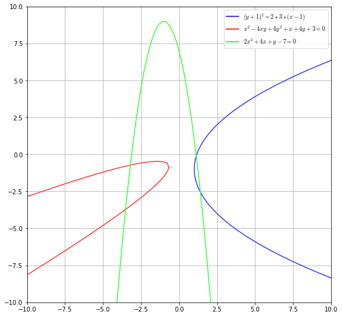

```python
X=numpy.linspace(start=-12,stop=12,num=100)
X,Y=numpy.meshgrid(X,X)
def parabole1(x0,y0,p,x,y):
    return (y-y0)**2-2*p*(x-x0)
def parabole2(a,b,c,d,e,f,x,y):
    return a*x**2+b*x*y+c*y**2+d*x+e*y+f
def parabole3(a,d,e,f,x,y):
    return a*x**2+d*x+e*y+f
f3=[parabole1(1,-1,3,X,Y),
    parabole2(1,-4,4,1,4,3,X,Y),
    parabole3(2,4,1,-7,X,Y)]
fig=pylab.figure(figsize=(9,9))
ax=fig.add_subplot(111); pylab.grid()
colors=['#3636ff','#ff3636','#36ff36']
lines=[Line2D([0],[0],color=c,linewidth=2,
       linestyle='-') for c in colors]
labels=['$(y+1)^2=2*3*(x-1)$',
        '$x^2-4xy+4y^2+x+4y+3=0$',
        '$2x^2+4x+y-7=0$']
[ax.contour(X,Y,f3[i],[0],colors=[colors[i]])
 for i in range(3)]
ax.set_xlim(-10,10); ax.set_ylim(-10,10)
ax.legend(lines,labels,loc=1); pylab.show()
```

```python
%%r
X<-Y<-seq(from=-12,to=12,by=0.2)
parabola1<-function(x0,y0,p,y){(y-y0)**2/2/p+x0}
parabola2<-function(a,b,c,d,e,f,X,Y){
    func<-function(x,y){a*x**2+b*x*y+c*y**2+d*x+e*y+f}
    Z<-outer(X,Y,func); Z[is.na(Z)] <- 0; Z}
parabola3<-function(a,d,e,f,x){-(a*x**2+d*x+f)/e}
X1<-sapply(Y,parabola1,x0=1,y0=-1,p=3)
Y3<-sapply(X,parabola3,a=2,d=4,e=1,f=-7)
XY<-parabola2(1,-4,4,1,4,3,X,Y)
dim(data.frame(XY))
```

```
[1] 121 121
```

```python
%%r
t(data.frame(XY[c(1:10),c(1:10)]))
```

```
     [,1]  [,2]  [,3]   [,4]   [,5]   [,6]   [,7]   [,8]   [,9]  [,10]
X1  87.00 92.04 97.16 102.36 107.64 113.00 118.44 123.96 129.56 135.24
X2  78.36 83.24 88.20  93.24  98.36 103.56 108.84 114.20 119.64 125.16
X3  70.04 74.76 79.56  84.44  89.40  94.44  99.56 104.76 110.04 115.40
X4  62.04 66.60 71.24  75.96  80.76  85.64  90.60  95.64 100.76 105.96
X5  54.36 58.76 63.24  67.80  72.44  77.16  81.96  86.84  91.80  96.84
X6  47.00 51.24 55.56  59.96  64.44  69.00  73.64  78.36  83.16  88.04
X7  39.96 44.04 48.20  52.44  56.76  61.16  65.64  70.20  74.84  79.56
X8  33.24 37.16 41.16  45.24  49.40  53.64  57.96  62.36  66.84  71.40
X9  26.84 30.60 34.44  38.36  42.36  46.44  50.60  54.84  59.16  63.56
X10 20.76 24.36 28.04  31.80  35.64  39.56  43.56  47.64  51.80  56.04
```

```python
%%r
svg(filename="Rplots.svg",width=7,height=7,pointsize=12,
    onefile=TRUE,family="sans",bg="white",
    antialias=c("default","none","gray","subpixel"))
cols<-c('#3636ff','#ff3636','#36ff36')
labs<-c('(y+1)^2=2*3*(x-1)',
        'x^2-4xy+4y^2+x+4y+3=0',
        '2x^2+4x+y-7=0')
contour(X,X,data.matrix(data.frame(XY)),
        levels=0,col=cols[2],lwd=3,
        xlim=c(-10,10),ylim=c(-10,10),
        xlab='x',ylab='y')
lines(X1,Y,col=cols[1],lwd=3)
lines(X,Y3,col=cols[3],lwd=3)
legend(1,10,labs,col=cols,lwd=3,cex=0.9)
grid(); dev.off()
```

## 4. Задание

Инициировать 3 кривые второго порядка с помощью уравнений в каноническом виде,

найти все их точки пересечения, изобразить кривые и точки на координатной плоскости,

используя SageMath, Numpy, SymPy, R.